# BRIDGE REPORT

Astrid

2022-11-18

# Methods

## Participants

```
##    study_arm   n
## 1:       EUC 893
## 2:       TSC 899
```

```
##    study_arm   n
## 1:       EUC 547
## 2:       TSC 568
```

### Drop-outs

```
##    study_arm   n
## 1:       EUC 157
## 2:       TSC 131
```

### demographic

- gender
- city

Gender in 2 arms for all participants(including drop-outs)

| study_arm | gender | n | pct |
| --- | --- | --- | --- |
| EUC | Female | 319 | 36% |
| EUC | Male | 573 | 64% |
| TSC | Female | 320 | 36% |
| TSC | Male | 579 | 64% |

City in 2 arms for all participants(including drop-outs)

| study_arm | city | n | pct |
| --- | --- | --- | --- |
| EUC | Kaduna | 210 | 23.5% |
| EUC | Kano | 443 | 49.6% |
| EUC | Zaria | 240 | 26.9% |
| TSC | Kaduna | 234 | 26.0% |
| TSC | Kano | 449 | 49.9% |
| TSC | Zaria | 216 | 24.0% |

Gender in 2 arms for completed participants

| study_arm | gender | n | pct |
| --- | --- | --- | --- |
| EUC | Female | 207 | 38% |
| EUC | Male | 340 | 62% |
| TSC | Female | 198 | 35% |
| TSC | Male | 370 | 65% |

City in 2 arms for completed participants

| study_arm | city | n | pct |
| --- | --- | --- | --- |
| EUC | Kaduna | 86 | 16% |
| EUC | Kano | 284 | 52% |
| EUC | Zaria | 177 | 32% |
| TSC | Kaduna | 100 | 18% |
| TSC | Kano | 308 | 54% |
| TSC | Zaria | 160 | 28% |

### intervals

**Expected schedule of follow-up visits** Only the first follow-up needs to be +/- 3 days, all else allow +/- 14 days.  
*Schedule:*  
* instance 1 - Week 1  
* instance 2 - Month 1  
* instance 3 - Month 2  
* instance 4 - Month 4  
* instance 5 - Month 6  
* instance 6 - Month 9  
* instance 7 - Month 12  
* instance 8 - Month 15  
* instance 9 - Month 18  
* instance 10 - Month 24  
*Expected time interval:*  
* v1: 7 +/- 3 from v0  
* v2: 28 +/- 14 from v0  
* v3: 28 +/- 14 from v2  
* v4: 56 +/- 14 from v3  
* v5: 56 +/- 14 from v4  
* v6: 84 +/- 14 from v5  
* v7: 84 +/- 14 from v6  
* v8: 84 +/- 14 from v7  
* v9: 84 +/- 14 from v8  
* v10: 168 +/- 14 from v9

Range of intervals between follow up visits, EUC

|  | d01 | d12 | d23 | d34 | d45 | d56 | d67 | d78 | d89 | d90 |
| --- | --- | --- | --- | --- | --- | --- | --- | --- | --- | --- |
|  | Min. :-28.000 | Min. :-40.00 | Min. : 0.00 | Min. : 0.00 | Min. :-12.00 | Min. : 0.00 | Min. : 0.0 | Min. : 40.00 | Min. : 0.00 | Min. : 13.0 |
|  | 1st Qu.: 7.000 | 1st Qu.: 21.00 | 1st Qu.:28.00 | 1st Qu.: 56.00 | 1st Qu.: 56.00 | 1st Qu.: 83.00 | 1st Qu.: 84.0 | 1st Qu.: 83.00 | 1st Qu.: 82.00 | 1st Qu.:167.0 |
|  | Median : 7.000 | Median : 21.00 | Median :28.00 | Median : 56.00 | Median : 56.00 | Median : 84.00 | Median : 84.0 | Median : 84.00 | Median : 84.00 | Median :168.0 |
|  | Mean : 8.579 | Mean : 22.09 | Mean :28.49 | Mean : 54.79 | Mean : 55.54 | Mean : 83.23 | Mean : 84.3 | Mean : 84.11 | Mean : 82.89 | Mean :168.6 |
|  | 3rd Qu.: 8.000 | 3rd Qu.: 21.00 | 3rd Qu.:28.00 | 3rd Qu.: 56.00 | 3rd Qu.: 56.00 | 3rd Qu.: 84.00 | 3rd Qu.: 85.0 | 3rd Qu.: 84.00 | 3rd Qu.: 84.00 | 3rd Qu.:172.0 |
|  | Max. :154.000 | Max. :121.00 | Max. :85.00 | Max. :129.00 | Max. :219.00 | Max. :183.00 | Max. :161.0 | Max. :174.00 | Max. :234.00 | Max. :217.0 |
|  | NA’s :9 | NA’s :18 | NA’s :33 | NA’s :49 | NA’s :78 | NA’s :104 | NA’s :117 | NA’s :126 | NA’s :155 | NA’s :266 |

Range of intervals between follow up visits, TSC

|  | d01 | d12 | d23 | d34 | d45 | d56 | d67 | d78 | d89 | d90 |
| --- | --- | --- | --- | --- | --- | --- | --- | --- | --- | --- |
|  | Min. :-307.000 | Min. :-10.00 | Min. :-56.00 | Min. :-49.00 | Min. : -7.00 | Min. :-281.00 | Min. : 11.00 | Min. : 0.00 | Min. :-650.00 | Min. :-198.0 |
|  | 1st Qu.: 7.000 | 1st Qu.: 21.00 | 1st Qu.: 28.00 | 1st Qu.: 56.00 | 1st Qu.: 56.00 | 1st Qu.: 84.00 | 1st Qu.: 84.00 | 1st Qu.: 84.00 | 1st Qu.: 82.00 | 1st Qu.: 167.0 |
|  | Median : 7.000 | Median : 21.00 | Median : 28.00 | Median : 56.00 | Median : 56.00 | Median : 84.00 | Median : 84.00 | Median : 84.00 | Median : 84.00 | Median : 168.0 |
|  | Mean : 7.656 | Mean : 22.93 | Mean : 29.25 | Mean : 54.34 | Mean : 55.48 | Mean : 83.19 | Mean : 84.45 | Mean : 83.78 | Mean : 83.04 | Mean : 169.9 |
|  | 3rd Qu.: 8.000 | 3rd Qu.: 23.00 | 3rd Qu.: 28.00 | 3rd Qu.: 56.00 | 3rd Qu.: 56.00 | 3rd Qu.: 84.00 | 3rd Qu.: 84.00 | 3rd Qu.: 84.00 | 3rd Qu.: 84.00 | 3rd Qu.: 172.0 |
|  | Max. : 103.000 | Max. :153.00 | Max. :169.00 | Max. :167.00 | Max. :112.00 | Max. : 157.00 | Max. :448.00 | Max. :168.00 | Max. : 445.00 | Max. : 901.0 |
|  | NA’s :28 | NA’s :39 | NA’s :55 | NA’s :68 | NA’s :80 | NA’s :91 | NA’s :105 | NA’s :109 | NA’s :148 | NA’s :259 |

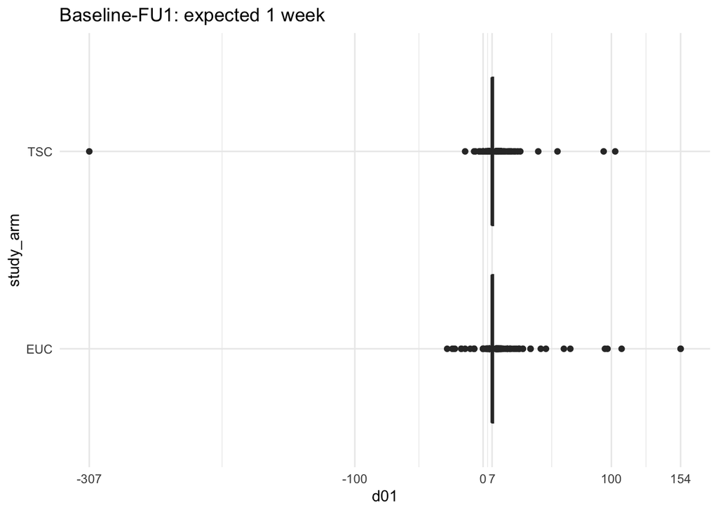

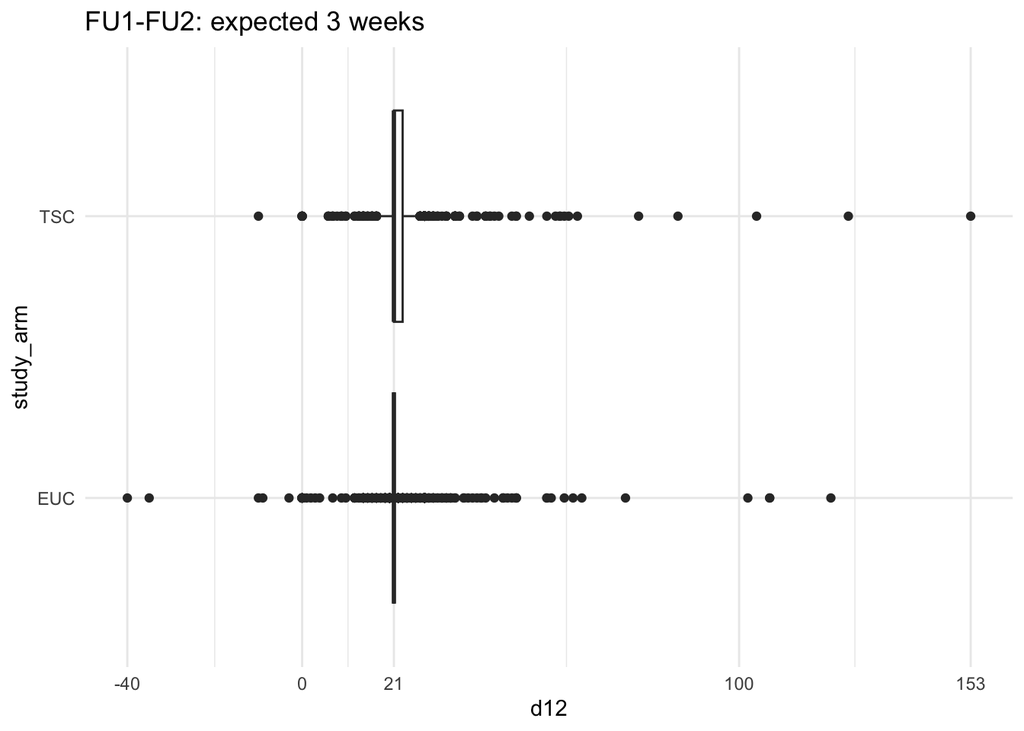

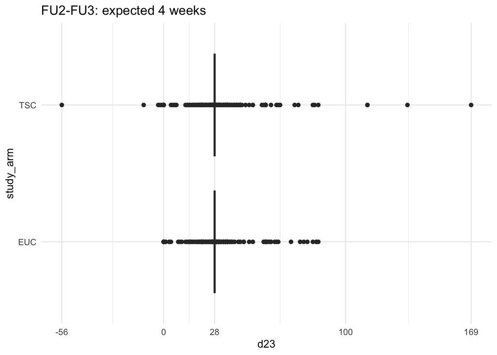

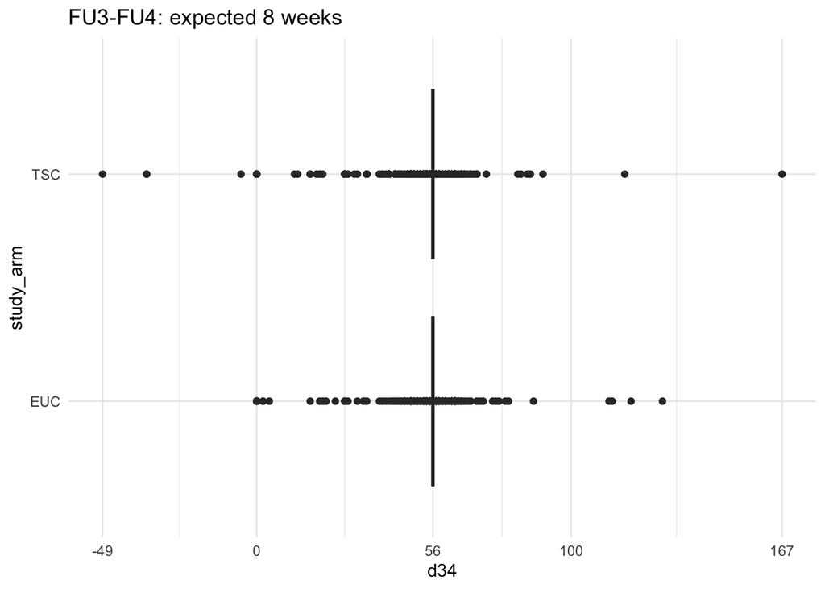

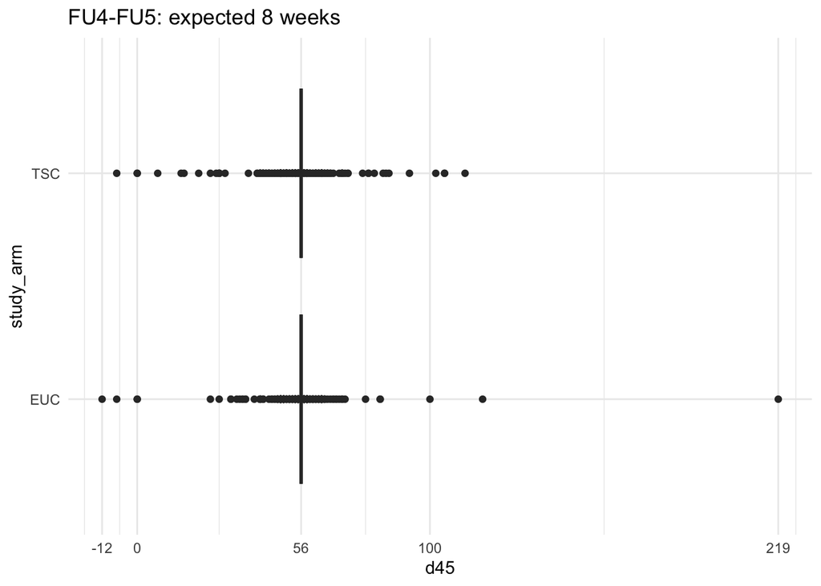

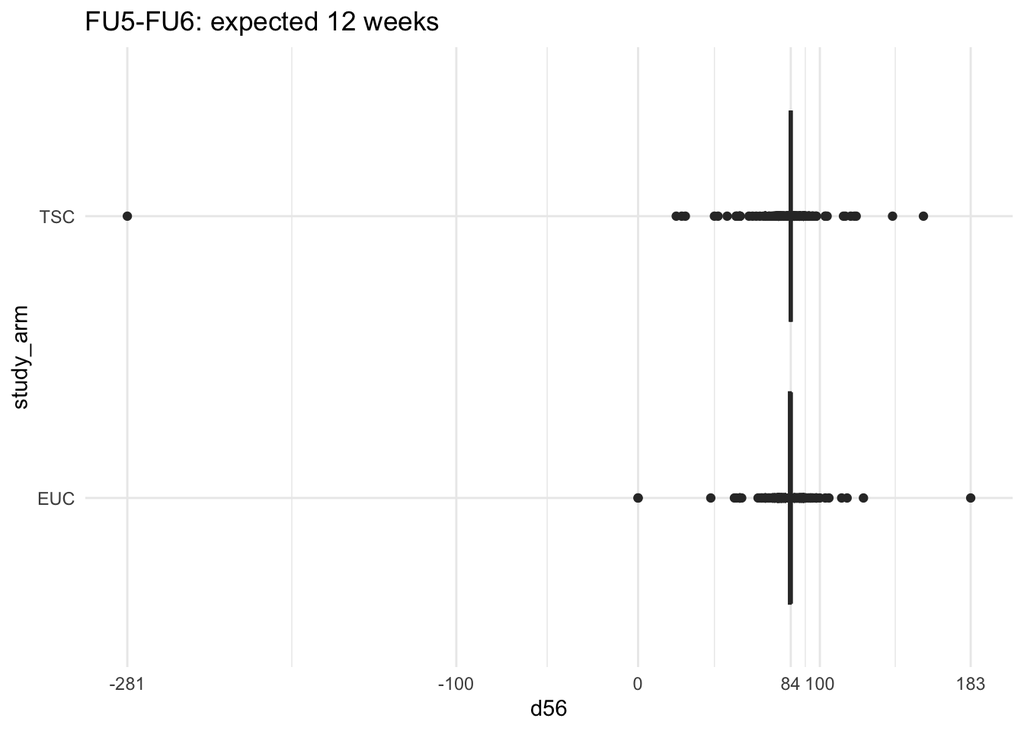

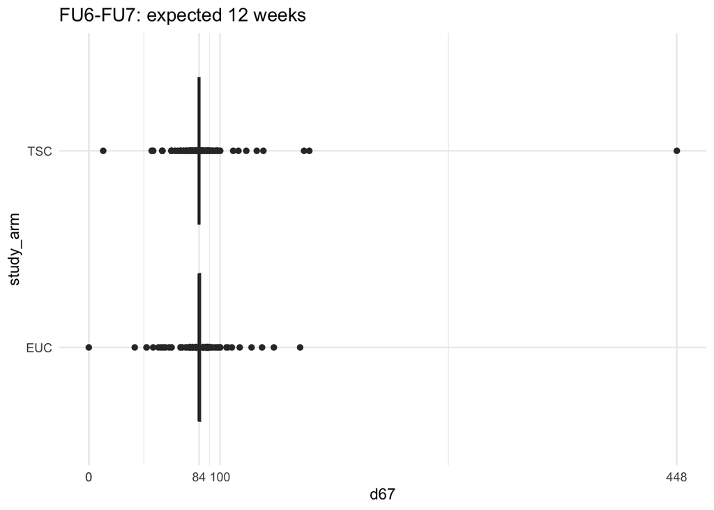

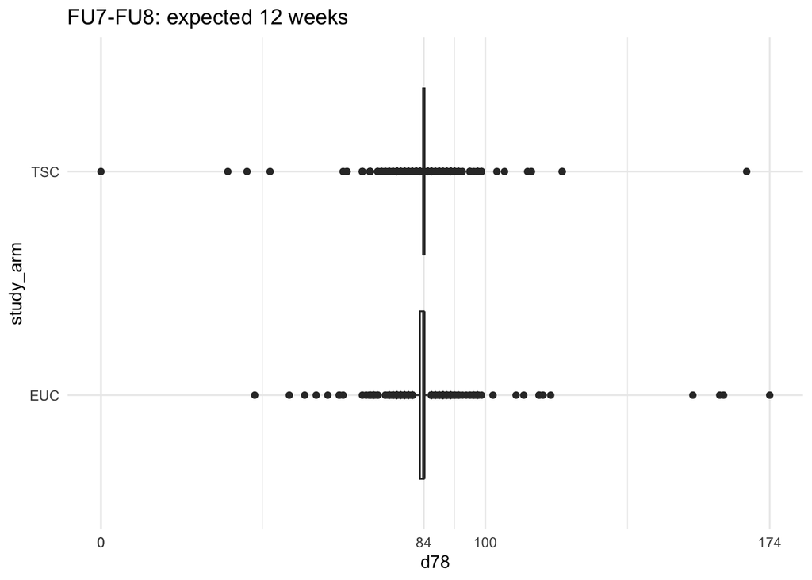

## Instruments

- VAS
  - For all ages, for all follow up visits
- QOLIE
  - QOLIE-AD-48: for 11 < age < 17
  - QOLIE-31: for age > 17
  - 3 times totally, should be screening(month 0), month 2, month 24.
  - **Question 16 and 18 (Cramer, 1999) in QOLIE-AD-48** are missing and then ignored from the survey.

### inclusion criteria

#### VAS

if Missed_fu is

- “No”,
- “No missed”,
- “None”,
- “N0”,
- “Not missed”,
- “NO”,
- “No miss”,
- “No messing”,
- “No missen”,
- “No missing”,
- “0”,
- “On time” the response will be included.

For the NA(blank answers) and “Visit Done”, we have no reasons to set them all as missing or not missing.  
So I use the important indices(**follow_up_care_form_complete**, **confirmseize**, **weight_fu_v2**, **confirm_seizure_class_v2**) to distinguish whether they are actually missing or not.

incomplete = 0 means completing all the key questions

| incomplete | missed_fu | n_inclusive | n_in_and_ex | pct |
| --- | --- | --- | --- | --- |
| 0 | NA | 14708 | 14708 | 100% |
| 0 | No | 266 | 266 | 100% |
| 0 | No missed | 64 | 64 | 100% |
| 0 | None | 44 | 44 | 100% |
| 0 | N0 | 39 | 39 | 100% |
| 0 | NO | 13 | 13 | 100% |
| 0 | Not missed | 12 | 12 | 100% |
| 0 | 0 | 10 | 10 | 100% |
| 0 | Visit done, the CHW was sick. | 4 | 4 | 100% |
| 0 | No missing | 2 | 2 | 100% |
| 0 | Visit done the patient travelled for sallah break. | 2 | 2 | 100% |
| 0 | Visit done. I was sick at the follow up time. | 2 | 2 | 100% |
| 0 | Visit done. The patient travelled. | 2 | 2 | 100% |
| 0 | No messing | 1 | 1 | 100% |
| 0 | No missen | 1 | 1 | 100% |
| 0 | On time | 1 | 1 | 100% |
| 0 | Visit done but the child lost wight becouse she have fever and abd pain send to Dr to see at Hospital | 1 | 1 | 100% |
| 0 | Visit done child have fever send Dr see | 1 | 1 | 100% |
| 0 | Visit done no seizures but the child is very slim due to lack of food my the mother | 1 | 1 | 100% |
| 0 | Visit done the child didn’t not have seizures but her condition is not good and wight is lost and no fever or diarrhoes l send them to see a Dr that Hospital | 1 | 1 | 100% |
| 0 | Visit done, but it was late because the patient travelled to Funtua LGA in Katsina State where there is not network communication. | 1 | 1 | 100% |
| 0 | Visit Done, Patient travelled with his mother | 1 | 1 | 100% |
| 0 | Visit Done, the CHW put to bed a baby during the follow up period and was unable to bring the tablet for synching. | 1 | 1 | 100% |
| 0 | Visit done, the CHW was nursing her child during the follow up period. | 1 | 1 | 100% |
| 0 | Visit Done, the CHW was nursing her sick infant child during the follow up period. | 1 | 1 | 100% |
| 0 | Visit done, The CHW was sick during the follow up period. | 1 | 1 | 100% |
| 0 | Visit done, the patient travelled and are now back home. | 1 | 1 | 100% |
| 0 | Visit done, the patient travelled but are now back home. | 1 | 1 | 100% |
| 0 | Visit done, the patient travelled for sallah break | 1 | 1 | 100% |
| 0 | Visit done. | 1 | 1 | 100% |
| 0 | Visit done. At first, the father said they travel for wedding, and they will spend 2 weeks, so after 2 weeks i call there number is not going so i desided to pay them a visit, today 6 oct 2021, yet th… | 1 | 1 | 100% |
| 0 | Visit done. I was ill during the time of the visit, i could not do it on time! | 1 | 1 | 100% |
| 0 | Visit done. I was sick - therefore, the visit was delayed. | 1 | 1 | 100% |
| 0 | Visit done. I was sick during the appointment date. | 1 | 1 | 100% |
| 0 | Visit done. I was sick during the follow up visif,so i could not do it on time. | 1 | 1 | 100% |
| 0 | Visit done. I was sick during the follow up visit, that is why the follow up was delay. | 1 | 1 | 100% |
| 0 | Visit Done. I was sick. | 1 | 1 | 100% |
| 0 | Visit Done. It is a phone visit, because the patient has moved to other part of the state and they couldn’t get measuring scale for height, head and arm circumference. | 1 | 1 | 100% |
| 0 | Visit done. It was delayed because the patient travelled. | 1 | 1 | 100% |
| 0 | Visit done. It was delayed because they relocated and their line was unreachable. | 1 | 1 | 100% |
| 0 | Visit done. It was delayed due to the fact that the father who normally brings the child to the followup was sick. Moreover, the CHW figured financial constraints with the father and intended to give … | 1 | 1 | 100% |
| 0 | Visit done. Patient couldn’t be reached. | 1 | 1 | 100% |
| 0 | Visit done. Patient relocated but we tracked them and they are able to come for both blinded physician and CHW visits today. | 1 | 1 | 100% |
| 0 | Visit done. She travelled at follow up time. | 1 | 1 | 100% |
| 0 | Visit done. The child had diarrhoea which made him loose 3kg of weight. | 1 | 1 | 100% |
| 0 | Visit done. The child had lost in weight due to malaria fever. But she has recovered. | 1 | 1 | 100% |
| 0 | Visit done. The CHW lost contact with the parents of the child until last Monday. As such, the visit is measured late. | 1 | 1 | 100% |
| 0 | Visit done. The CHW regains contact with the mother of the child after over 3 months of tireless tracking. The mother travelled to Niger Republic. The notification of the journey to the CHW failed. Sh… | 1 | 1 | 100% |
| 0 | Visit done. The CHW was sick at the time of the visit. | 1 | 1 | 100% |
| 0 | Visit done. The delay was due to the fact their phone was unreachable. | 1 | 1 | 100% |
| 0 | Visit done. The follow up was done within the window. The CHW lost her father and was in mourning. | 1 | 1 | 100% |
| 0 | Visit done. The increased in previous weight occurs due to problem of weighing scale used before receiving the new one for the study. | 1 | 1 | 100% |
| 0 | Visit done. The mother can not afford to buy the drug any more due to financial constraints, and the father is not giving any help.That is why the mother is trying to switch to traditional medicine bu… | 1 | 1 | 100% |
| 0 | Visit done. The mother was sick. | 1 | 1 | 100% |
| 0 | Visit Done. The parent couldn’t be reached. | 1 | 1 | 100% |
| 0 | Visit done. The parent relocated to Yobe state. | 1 | 1 | 100% |
| 0 | Visit done. The parent’s phone couldn’t be reached. | 1 | 1 | 100% |
| 0 | Visit done. The parents relocated to a new location without notice and their contact couldn’t be reached until last Thursday 2nd September 2021. Therefore, the visit was delayed. | 1 | 1 | 100% |
| 0 | Visit Done. The patient didn’t come on the appointed date due to his mother’s ilness. | 1 | 1 | 100% |
| 0 | Visit done. The patient is currently living with her grandmother in Abuja. She’s returning to Kano only when secondary schools closes for sessional holidays. As such, the followup visit was delayed. | 1 | 1 | 100% |
| 0 | Visit done. The patient traveled at the appointment date. | 1 | 1 | 100% |
| 0 | Visit done. The patient travelled since before Sallah break. | 1 | 1 | 100% |
| 0 | Visit Done. The patient travelled to another state in Nigeria which resulted in the delay for this follow up. | 1 | 1 | 100% |
| 0 | Visit Done. The patient travelled to Jigawa State. | 1 | 1 | 100% |
| 0 | Visit done. The patient travelled to their Village. | 1 | 1 | 100% |
| 0 | Visit done. The patient travelled. Later, I was sick and admitted into hospital. | 1 | 1 | 100% |
| 0 | Visit done. The patient was missing since mid June 2021. Parents were lucky to find the child end of August 2021. | 1 | 1 | 100% |
| 0 | Visit Done. The patient’s mother was not around. | 1 | 1 | 100% |
| 0 | Visit done. The reason it was delayed is because the patient travelled. | 1 | 1 | 100% |
| 0 | Visit done. The visit wasn’t done at appointment date because his mother was sick at the time. | 1 | 1 | 100% |
| 0 | Visit done. They missed appointment because of transportion. | 1 | 1 | 100% |
| 0 | Visit done. They patient travelled outside Kano. | 1 | 1 | 100% |
| 0 | Visit done. They temporarily relocated to Lagos. | 1 | 1 | 100% |
| 0 | Visit done. They travel at the appointment date. | 1 | 1 | 100% |
| 0 | Visit done. They traveled at the appointment date. | 1 | 1 | 100% |
| 0 | Visit done. They traveled. | 1 | 1 | 100% |
| 0 | Visit done. They travelled at the follow up time. | 1 | 1 | 100% |
| 0 | Visit done. They travelled to Bauchi state at that time. | 1 | 1 | 100% |
| 0 | Visit done. They were not around at that time. | 1 | 1 | 100% |
| 0 | Visit done.The patient was not available on the exact follow up day. | 1 | 1 | 100% |

#### QOLIE

**Source**

1. from both Screening and Follow up visits;
2. including both QOLIE-31 and QOLIE-AD-48.

**Logic for selecting same-day QOLIE records**

For every participant, if there exists 2 QOLIE records on the same day,

1. choose the one with type(QOLIE-31/QOLIE-AD-48) more eligible for the age(11-17 use QOLIE-AD-48, >18 use QOLIE-31);
2. if the same QOLIE type, choose the one with less missing domain and less missing items;
3. if still the same, choose the one with bigger *instance*.

**Logic for i-th QOLIE**

For every participant,

1. the baseline date is obtained from *date_consent_screen* or *dataconsentenroll*, choosing one based on *ev0*;
2. 0th QOLIE(**first**): the first occurence of QOLIE records, no matter whether the date is on or before or after the baseline date, and no matter whether the record is from Screening or Follow up Visits, except from one case: the date is after “2022-01-01”;
3. 3rd QOLIE(**last**): the last time of QOLIE records and the date is after “2022-01-01”. For those who have only one time QOLIE record, if the date is after “2022-01-01”, the record will be labeled as the 3-rd, as the participants are only old enough(>11) for the last time of visits(maybe we can compare their previous VAS score and this time of QOLIE);
4. 1st or 2nd: the ones between the 0th and 3rd. For participants with 4 times of QOLIE and participants with 2 times of after-“2022-01-01” QOLIE, the 2nd will be filled – they could also be dropped as they are not so consistent with the schedule;
5. For the records with “NA” dates, the order will depend on the *instance*. I prefer to put them on the 2nd, as they might be dropped as the data includes too much noises.

# Results

see aim3_brief.